# Where Should Activities Be Located?

Stephen Weymouth

Dean’s Professor

2026-09-28

# In 2006 the ports of Hong Kong and Shenzhen shipped one container every second.

## Your IB Voice

Explain the location

Fallows claims that neither a stronger Chinese currency nor an end to subsidies would move Shenzhen’s jobs back to the United States. What attracts production to the Pearl River Delta?

**10 minutes** · Individual · Notes permitted

## Competing explanations

What attracts production to the Pearl River Delta?

Wages in Shenzhen are a fraction of U.S. wages.

Suppliers and parts sit within a mile of the factory.

The government built the zone and waived the duties.

People like Liam Casey know where the factories are.

Workers can be retasked faster than machines.

# Why is the work in Shenzhen, and why does it stay?

## Back to the future

In 1980 Beijing made Shenzhen a special economic zone beside Hong Kong (harbor + airport).

Nearly every rule that restricted business was changed or removed.

Imported parts entered the processing zones duty-free, and the goods built from them left untaxed

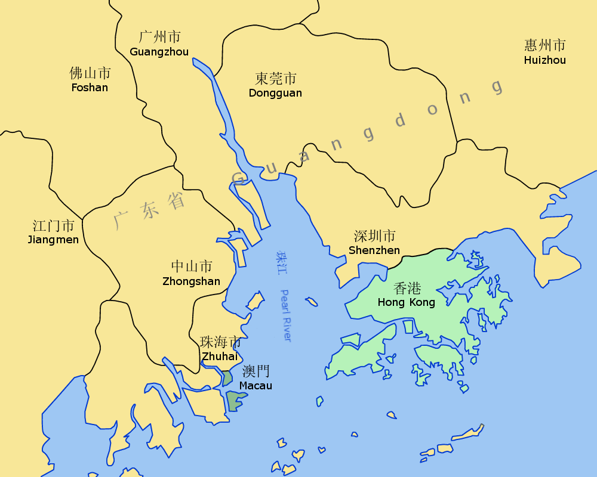

Croquant, [*Pearl River Delta Area*](https://commons.wikimedia.org/wiki/File:Pearl_River_Delta_Area.png), 2007 · Wikimedia Commons, CC BY 3.0.

# Workers came young from the countryside

A shift ran twelve hours, six or seven days a week.

## Small-firm Taiwanese approach

[figure not shown]

Foxconn’s first Dell and Compaq cases, made in Shenzhen in 1998 · Lhzss8, [Wikimedia Commons](https://commons.wikimedia.org/wiki/File:深圳富士康生产的第一批电脑机箱.jpg), 2019, CC BY-SA 4.0.

Taiwanese entrepreneurs built thousands of small family firms where Japan and Korea had built national champions.

Foxconn, the largest of them, was No. 206 on the 2006 Fortune Global 500.

Foreign buyers “don’t know where to start.”

## Liam Casey sells knowledge of the factories

Casey, from Cork, set up PCH near Shenzhen a year after he first first visited Asia.

PCH had 800 employees and sales of about $125 million in 2006.

His map holds every supplier’s GPS position, photographs, and travel times.

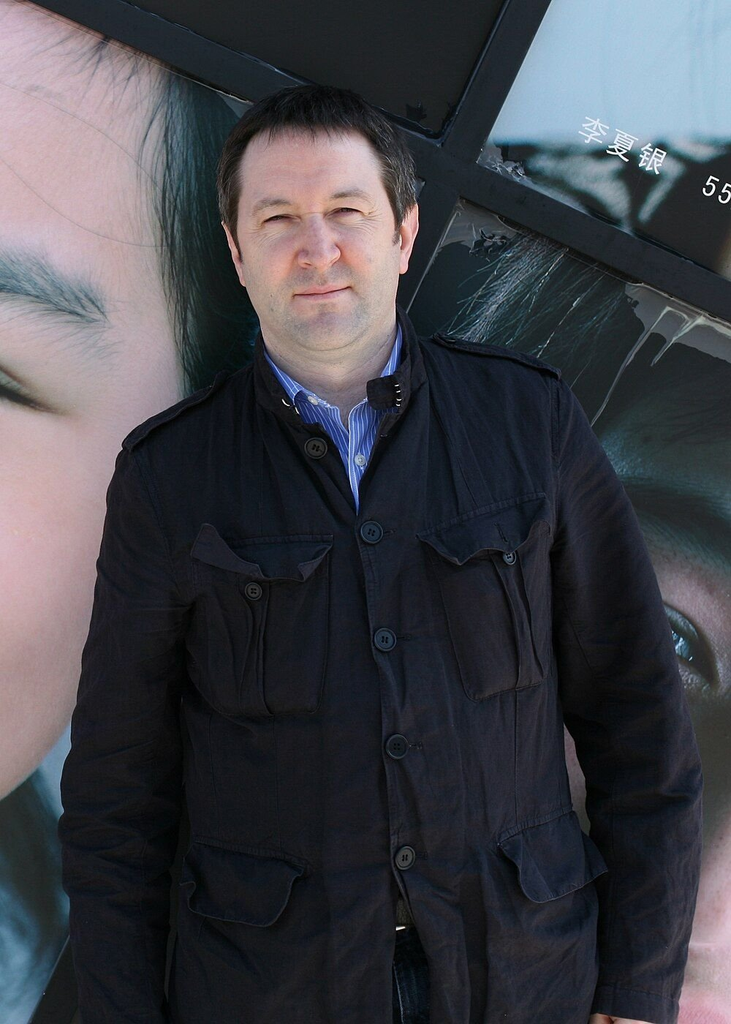

Robert Scoble, *Bigger than life*, 2008 · Wikimedia Commons, CC BY 2.0.

“Supply chain is intellectual property.”

# The SEG market stacks seven floors of parts a short drive from hundreds of factories.

## Labor demand in a pre-automation era

[figure not shown]

International Federation of Robotics, [*World Robotics 2017*](https://ifr.org/news/robot-density-rises-globally/), robot density in 2016.

“Machines need to be reprogrammed. You can have people doing something entirely different next week.”

Shenzhen’s plants lacked robots because retasking people was cheaper than reprogramming machines.

Abundant, lower wage labor enables flexibility

## An Illinois order ships from Shenzhen in 48 hours

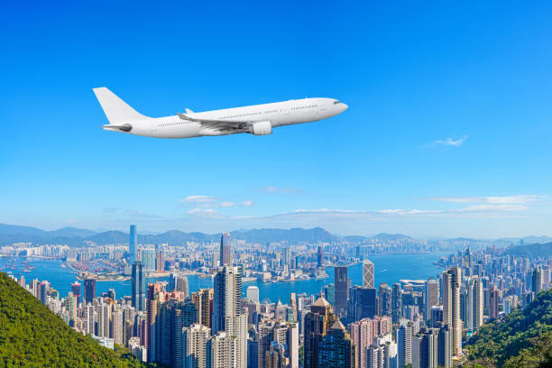

Approach to Hong Kong International Airport · course files.

[figure not shown]

The night shift packs before the 9 a.m. courier, so the time difference became an asset.

# “People think China is cheap, but really, it’s fast.”

# The cluster is fast. Who gets paid for it?

## Value sits at the two ends of the ‘smiley’ curve

[figure not shown]

China’s work sits in the middle stages, and brand, design, retail, and service stay with the buyer.

## A $1,000 laptop leaves $30 to $40 in China

The money follows the scarce input, so chips and software earn the most and assembly the least.

Three to four percent of the price stayed in China.

[figure not shown]

Fallows (2007), a factory manager’s estimate for one $1,000 laptop.

Chinese workers earning $1,000 a year help U.S. designers and retailers earning $1,000 a week earn more.

## Apple kept 58 percent of the iPhone’s price

[figure not shown]

Kraemer, Linden, and Dedrick, [*Capturing Value in Global Networks: Apple’s iPad and iPhone*](https://economiadeservicos.com/wp-content/uploads/2017/04/value_ipad_iphone.pdf), UC Irvine, 2011, Table 1.

Researchers at UC Irvine traced every dollar of the 2010 iPhone 4’s $549 price.

Assembly earned little because most could do it, and design and brand earned most because nobody else could.

# Why do different stages of a product go to different countries?

## Labor intensity differs across industries

[figure not shown]

OECD, [*STAN Database for Structural Analysis*](https://data-explorer.oecd.org/), 2025 edition: United States, 2021, compensation of employees as a share of value added.

In labor-intensive industries wages decide the cost of production, and in capital-intensive ones they hardly matter.

An activity is labor-intensive when workers take most of its value added and capital-intensive when plants and machines do.

## Each part of the laptop came from a different place

Screens and drives need costly plants, and came from Korea, Japan, Taiwan, and Singapore.

Keyboards, power supplies, and assembly need workers, and were done in China.

[figure not shown]

Parts of one product lean on different inputs, so they need not be made in one place.

## An activity goes where its heaviest input is cheap

[figure not shown]

U.S. Bureau of Labor Statistics, [*International Comparisons of Hourly Compensation Costs in Manufacturing, 2008*](https://www.bls.gov/news.release/archives/ichcc_08262010.htm), 2010; China and India are BLS estimates.

A stage that is mostly labor cost a twentieth as much in China, and a stage that is mostly machines cost about the same anywhere.

A place has a **comparative advantage** in the activities that use its abundant input most heavily, because that input is cheaper there.

## Trade follows endowments and intensities

[figure not shown]

China has many workers per machine and the United States many machines per worker, so labor-intensive goods cost less to make in China and capital-intensive goods in the United States.

Heckscher and Ohlin predicted that a country exports the goods that use its abundant input most heavily and imports those that use its scarce one.

## China exported the goods that use the most labor

China exported labor-intensive goods and the United States capital-intensive ones.

Electronics sits on both sides because China assembled and the United States made the chips.

[figure not shown]

OECD, [*Trade in Value Added*](https://www.oecd.org/en/topics/sub-issues/trade-in-value-added.html), 2025 edition: gross exports by industry, 2005; industries in the order of the labor-share chart.

The theorem holds for stages of a product, not only for industries.

# What explains the location of production?

## Density itself becomes an input

[figure not shown]

World Bank, [*World Development Indicators*](https://data.worldbank.org/indicator/TX.VAL.TECH.CD), high-technology exports (UN Comtrade), 2023.

The advantage is the other firms already there: suppliers, customers, specialists

**Agglomeration economies** are cost and speed advantages a firm gets only because other firms and workers are already nearby.

## The RMB appreciated a third and exports still tripled

[figure not shown]

Federal Reserve Board via [FRED](https://fred.stlouisfed.org/series/EXCHUS), series EXCHUS (yuan per dollar, monthly, averaged by year), and World Bank, [*World Development Indicators*](https://data.worldbank.org/indicator/TX.VAL.MRCH.CD.WT), merchandise exports (WTO), 2005 to 2015.

Fallows wrote that the RMB’s value “should rise, and it will,” but that no level would bring the jobs back to the U.S.

## In real terms the RMB appreciated by half by 2015

2005-2015: Prices rose faster in China than abroad, so the RMB appreciated more in real terms than in nominal terms.

Since 2022 lower inflation in China has made its goods cheaper again while the currency held.

[figure not shown]

Bank for International Settlements, [*Effective exchange rate indices*](https://data.bis.org/topics/EER), broad basket, nominal and CPI-based real, annual averages.

The real exchange rate is the nominal rate adjusted for prices at home and abroad, so a real appreciation means Chinese goods cost more in foreign goods.

## The maker in Shenzhen gets $2 of a $30 cable

[figure not shown]

Fallows (2007), retail prices of one cable sold under three labels and the payment to its maker.

Brand, distribution, and retail take the rest, so the factory’s price is a small part of what the shopper pays.

Ending every subsidy might lift the $2 to $3 or $4, enough to send the next plant to Vietnam but not to bring the work back to the United States.

## As wages rose, China’s factories bought robots

When labor stopped being cheap, the plants that stayed replaced workers with machines.

The assembly that needed the cheapest labor went elsewhere.

[figure not shown]

International Federation of Robotics, [*World Robotics*](https://ifr.org/ifr-press-releases/news/global-robot-density-in-factories-doubled-in-seven-years), 2017 and 2024 editions.

As a place’s inputs change, the activities it attracts change with them.

## China’s exports moved up the value chain by 2022

Textiles and apparel lost half their share while machinery, electrical equipment, and vehicles gained.

Electrical equipment grew on batteries and solar (not appliances): lithium-ion battery exports rose from $4 billion in 2012 to $51 billion in 2022.

[figure not shown]

OECD, [*Trade in Value Added*](https://www.oecd.org/en/topics/sub-issues/trade-in-value-added.html), 2025 edition: China’s gross exports by industry, 2005 and 2022, the latest year available; same industries, order, and scale as the 2005 chart.

Endowments are not fixed, so the trade pattern Heckscher and Ohlin predict moves as a country’s inputs change.

## The next plant went to Vietnam

[figure not shown]

World Bank, [*World Development Indicators*](https://data.worldbank.org/indicator/TX.VAL.TECH.CD), high-technology exports (UN Comtrade), 2008 to 2023, indexed to 2008; each gridline doubles.

Vietnam grew from a base a hundredth of China’s, and most of the parts it assembles still come from China.

The labor-intensive stage moved on when China’s labor stopped being cheap, and the supplier base stayed.

# Group Activity: Locate One Activity in Your Industry

## Locate one activity in your industry

1. **Select** one activity in your industry’s network, good or service, and the country where it concentrates.
2. **Diagnose** the input it leans on most, why that input is cheap there, and what has gathered around it.
3. **Recommend** where the next plant, office, lab, or data center should go.
4. **Defend** the choice against a rival country with the same cheap input.

**15 minutes** · Industry teams · One annotated list

## Report out

What’s a key input and where is it produced?

## Designed in California, assembled in China

[figure not shown]

Design happens where engineers are abundant, and assembly where workers and suppliers are abundant.

Raimond Spekking, *iPhone 5s (model A1457)*, 2021 · Wikimedia Commons, CC BY-SA 4.0, cropped.

## Takeaways

Where does an activity go, and what keeps it there?

An activity goes to the country where the input it uses most is cheapest.

It moves there only if shipping the output costs less than the saving on that input.

Once firms and workers gather in one place, the density itself becomes an advantage.

When the input stops being cheap, the next plant goes elsewhere and the suppliers stay.